# Demo Análisis de datos ómicos

```r
# Package required to call 'freq' and 'descr' functions (descriptive statistics)
library(summarytools)
# Package required to call 'ggplot' function (graphical tools)
library(ggplot2)
# Package required to call 'ggarrange' function (graphical tools)
library(ggpubr)
# Package required to call 'read.spss' function (loading '.spss' data format)
library(foreign)
# Package required to call 'read_xlsx' function (loading '.xlsx' data format)
library(readxl)
# Package required to load the data set 'RBGlass1'
library(archdata)
# Package required to call 'cortest.bartlett' function
library(psych)
# Package required to call 'fviz_pca_var, fviz_pca_ind and fviz_pca' functions
library(factoextra)
# Package required to call 'scatterplot3d' function
library(scatterplot3d)

library(DESeq2)
library(edgeR)
library(pheatmap)
library(RColorBrewer)
library(cluster)
library(ggdendro)
library(corrplot)
```

# Carga de datos

Cargamos los datos, previamente descargados de la base de datos del proyecto GEO. En concreto se ha descargado una matriz de expreesión génica en la que se midió la expresión de 39376 genes en 12 muestras. Nueve de ellas corresponden con pacientes en estado metastásico, tres de los cuales tienen metástasis hepática, tres tumores primariios y tres correesponden a tejidos normales adjacentes. Las 3 restantes son muestras de pacientes sin metástasis, pero con tumores primarios.

```r
data <- read.csv("GSE92914_raw_counts.csv", sep="", header=TRUE, row.names=1)
```

Como puede ser que haya genes que tengan conteos nulos en todas las muestras, los eliminamos.

```r
data <- data[rowSums(data)!=0,]
```

Vamos a crear un dataFrame nuevo en el que a cada muestra GSM se le asocie su condición experimental, lo cual va a ser útil para luego hacer un análisis de expresión diferencial.

```r
condiciones <- c("LM", "MT", "PN",  # Paciente 1
                "LM", "MT", "PN",  # Paciente 2
                "LM", "MT", "PN",  # Paciente 3
                "NM", "NM", "NM")  # Pacientes 4-6 sin metástasis

group <- factor(condiciones)

# Crear el sampleTable
sampleTable <- data.frame(
  row.names = colnames(data),
  condition = group
)

# Verificar sampleTable
print(sampleTable)
```

```
##            condition
## GSM2440320        LM
## GSM2440321        MT
## GSM2440322        PN
## GSM2440323        LM
## GSM2440324        MT
## GSM2440325        PN
## GSM2440326        LM
## GSM2440327        MT
## GSM2440328        PN
## GSM2440329        NM
## GSM2440330        NM
## GSM2440331        NM
```

# Análisis de componentes principales

Veamos en primer lugar que las variables están relacionadas mediante el cálculo de la matriz de correlación:

```r
matriz_correlacion <- cor(data)
matriz_correlacion
```

```
##            GSM2440320 GSM2440321 GSM2440322 GSM2440323 GSM2440324 GSM2440325
## GSM2440320  1.0000000  0.7614254  0.8673491  0.9199003  0.8234021 0.35489619
## GSM2440321  0.7614254  1.0000000  0.6873200  0.6924040  0.6259413 0.30001779
## GSM2440322  0.8673491  0.6873200  1.0000000  0.8631684  0.8625439 0.35417472
## GSM2440323  0.9199003  0.6924040  0.8631684  1.0000000  0.8189093 0.32834765
## GSM2440324  0.8234021  0.6259413  0.8625439  0.8189093  1.0000000 0.34844424
## GSM2440325  0.3548962  0.3000178  0.3541747  0.3283477  0.3484442 1.00000000
## GSM2440326  0.8255994  0.7650700  0.8220596  0.8704346  0.7103560 0.29992262
## GSM2440327  0.7212731  0.6561012  0.7996667  0.7027800  0.5831377 0.31253653
## GSM2440328  0.7875345  0.6360534  0.8951162  0.7847030  0.7383896 0.33380961
## GSM2440329  0.7145666  0.5734754  0.8087305  0.7162936  0.6559068 0.29350361
## GSM2440330  0.6345234  0.5010020  0.6554178  0.6404024  0.4650842 0.21581635
## GSM2440331  0.2517190  0.4741342  0.2794825  0.2489470  0.2302663 0.09538228
##            GSM2440326 GSM2440327 GSM2440328 GSM2440329 GSM2440330 GSM2440331
## GSM2440320  0.8255994  0.7212731  0.7875345  0.7145666  0.6345234 0.25171901
## GSM2440321  0.7650700  0.6561012  0.6360534  0.5734754  0.5010020 0.47413416
## GSM2440322  0.8220596  0.7996667  0.8951162  0.8087305  0.6554178 0.27948246
## GSM2440323  0.8704346  0.7027800  0.7847030  0.7162936  0.6404024 0.24894695
## GSM2440324  0.7103560  0.5831377  0.7383896  0.6559068  0.4650842 0.23026630
## GSM2440325  0.2999226  0.3125365  0.3338096  0.2935036  0.2158164 0.09538228
## GSM2440326  1.0000000  0.7660164  0.7907133  0.7184008  0.7406551 0.27699740
## GSM2440327  0.7660164  1.0000000  0.8457690  0.7655575  0.7791789 0.43756261
## GSM2440328  0.7907133  0.8457690  1.0000000  0.8098220  0.7113677 0.29065919
## GSM2440329  0.7184008  0.7655575  0.8098220  1.0000000  0.6436310 0.33390414
## GSM2440330  0.7406551  0.7791789  0.7113677  0.6436310  1.0000000 0.29092614
## GSM2440331  0.2769974  0.4375626  0.2906592  0.3339041  0.2909261 1.00000000
```

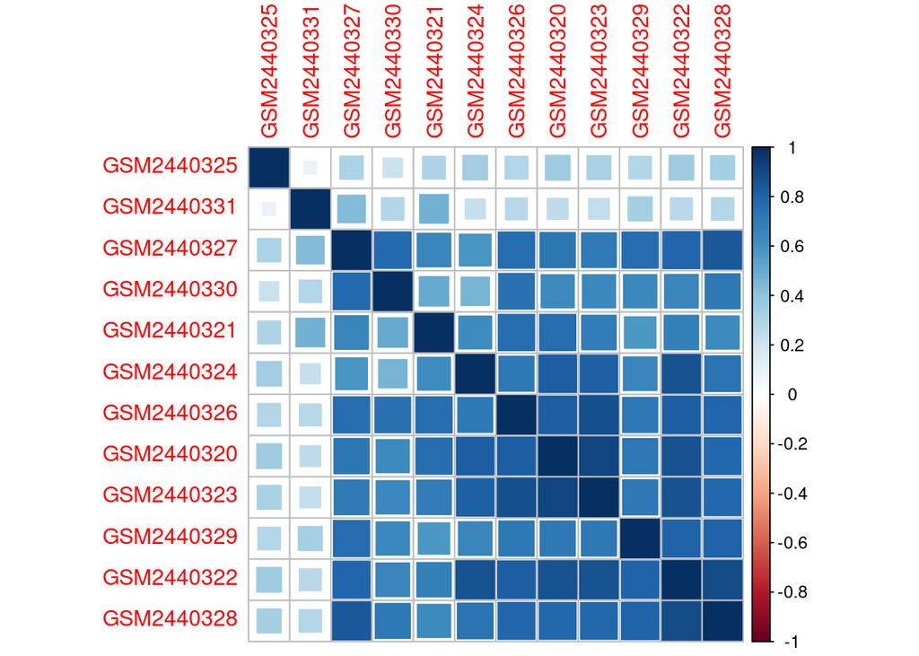

```r
corrplot(matriz_correlacion,method = "square", order = "hclust")
```

Observamos que la mayoría de las variables están altamente correladas, exceptuando las GSM2440325 y GSM2440331.

Para obtener las componentes principales, vamos a hacer uso de la función *prcomp*, aunque antes prepararemos los datos. Los datos RNA-seq crudos (la matriz de recuentos que hemos descargado), son counts enteros que vienen sin normalizar, tienen una distribución muy sesgada, muchos ceros y valores muy grandes, y no son adecuados para un PCA directo porque en PCA se asume que las variables son cuantitativas continuas y que están en la misma escala. Usaremos algunas funciones propias del paquete Bioconductor.

```r
# análisis de los conteos con edgeR
dgelist <- DGEList(counts = data, group = group)

# normalización
dgelist <- calcNormFactors(dgelist)

# Dispersión común
dgelist <- estimateCommonDisp(dgelist)
dgelist <- estimateTagwiseDisp(dgelist)

# Medimos el nivel de expresión de un gen
expr_genes <- cpm(dgelist, normalized=TRUE, log = TRUE)
```

Procedemos a hacer el análisis de componentes principales una vez los datos están listos para ello:

```r
pca <- prcomp(t(expr_genes))
```

```r
pca_data <- as.data.frame(pca$x)
pca_data$group <- condiciones
pca_data$sample <- rownames(pca_data)

# Varianza explicada
var_exp <- pca$sdev^2 / sum(pca$sdev^2)
cumulative_var_exp <- cumsum(var_exp)

cumulative_var_exp
```

```
##  [1] 0.2902819 0.4517593 0.5771578 0.6588475 0.7258160 0.7910407 0.8407787
##  [8] 0.8837994 0.9245776 0.9625224 1.0000000 1.0000000
```

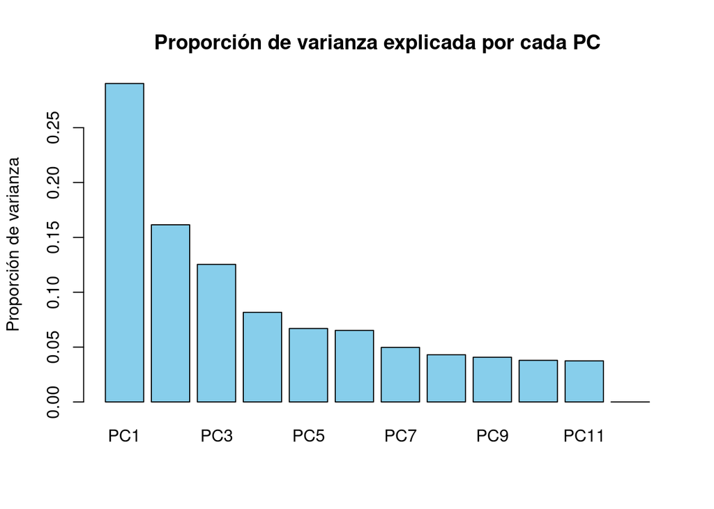

```r
# Scree plot
barplot(var_exp, main="Proporción de varianza explicada por cada PC",
        col="skyblue", names.arg=paste0("PC", 1:length(var_exp)),
        ylab="Proporción de varianza")
```

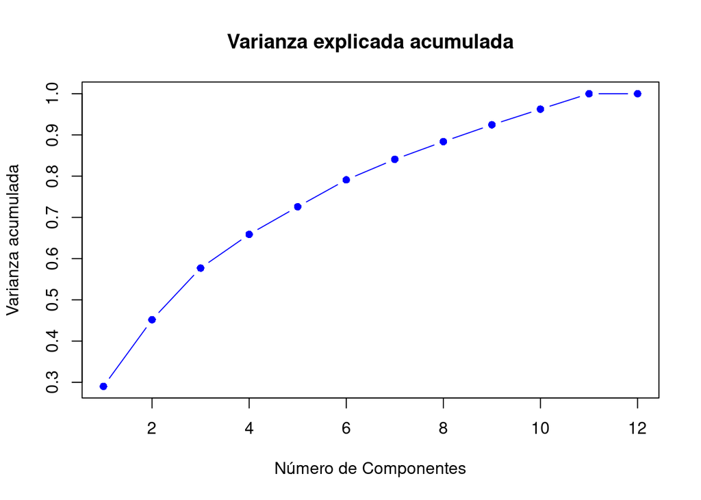

```r
plot(cumulative_var_exp, type="b", pch=16, col="blue",
     main="Varianza explicada acumulada",
     xlab="Número de Componentes", ylab="Varianza acumulada")
```

### ¿Qué se observa?

Podemos ver que solo las dos primeras componentes principales ya explican el 45.1% de la varianza total. Esto nos dice que si visualizamos las muestras en un gráfico 2D, ya podríamos ver si las muestras tienden a agruparse según sus tipos (LM,MT,PN,NM).

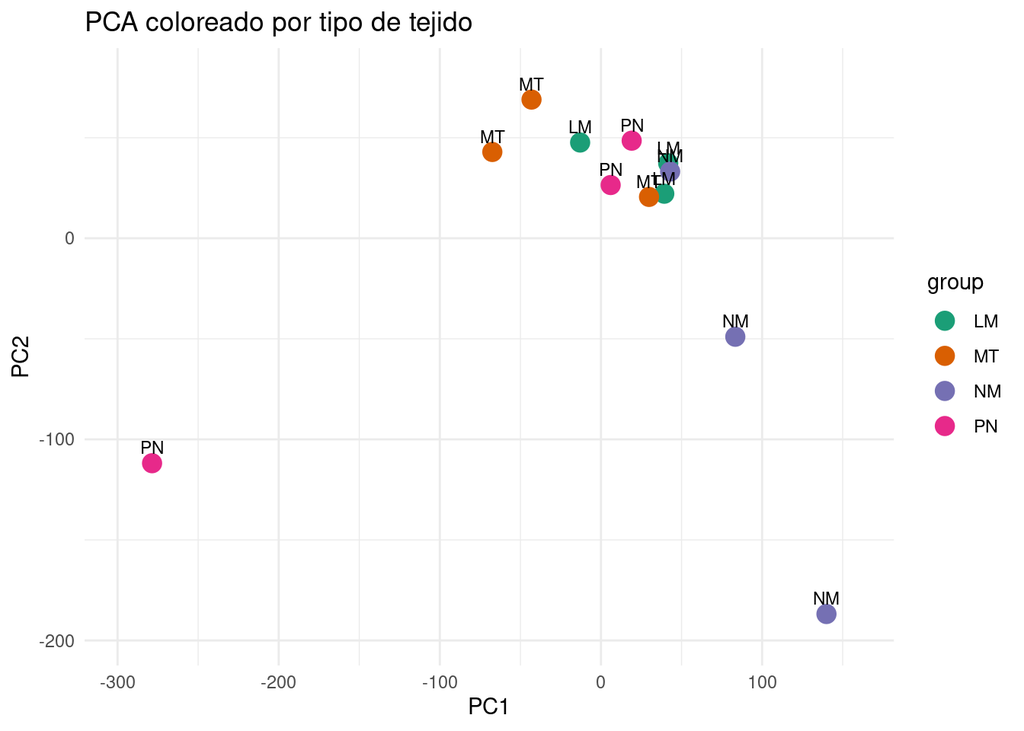

```r
# PCA plot coloreado por grupo
ggplot(pca_data, aes(x=PC1, y=PC2)) +
  geom_point(size=4, aes(color=group)) +
  geom_text(vjust=-0.7, size=3, aes(label = group)) +
  theme_minimal() +
  ggtitle("PCA coloreado por tipo de tejido") +
  scale_color_brewer(palette="Dark2") +
  scale_x_continuous(expand = expansion(mult = 0.1)) +
  scale_y_continuous(expand = expansion(mult = 0.1))
```

Las muestras de los pacientes metastásicos (LM,MT,PN), están bastante juntas, lo cual puede indicar que sus perfiles de expresión están más próximos entre sí que respecto a las muestras NM. ¿Y esto que puede querer decir? Que incluso el tejido “normal” adyacente(PN) de pacientes con metástasis, tienden a compartir alteraciones transcriptómicas con los tumores, aunque no podemos generalizar porque vemos un punto PN que aparece muy separado en el eje PC1, lo cual indica que tiene un perfil de expresión muy distinto al resto.

Podemos además ver los genes que más y menos contribuyen a PC1 y PC2:

```r
cargas <- pca$rotation

# mayores contribuciones positivas
head(sort(cargas[,1],decreasing = TRUE),10)
```

```
##       1800      27290      84951  101927125  105377108      23624       3934
## 0.02843508 0.02748468 0.02644922 0.02599098 0.02583460 0.02533638 0.02508028
##     118471       3875     113220
## 0.02492682 0.02480649 0.02466148
```

```r
# mayores contribuciones negativas
head(sort(cargas[,1]),10)
```

```
##        7060       26353       10586        9464        2273        8436
## -0.03108603 -0.03095290 -0.02911857 -0.02831108 -0.02824608 -0.02817384
##        4884        8404         477        4629
## -0.02804323 -0.02699416 -0.02670994 -0.02648161
```

# Análisis de expresión diferencial

https://bioconductor.org/packages/devel/bioc/vignettes/DESeq2/inst/doc/DESeq2.html

Para llevar a cabo el análisis de expresión diferencial a partir de la matriz de expresión génica descargada, vamos a hacer uso del paquete DESeq2 de Bioconductor. Hemos de tener en cuenta que, como entrada, el paquete DESeq2 espera datos de conteo obtenidos de RNA-seq u otra técnica de secuenciación, en la forma de matriz de enteros. Los elementos de la matriz no deben estar normalizados.

La clase de objeto utilizada por el paquete DESeq2 para almacenar los recuentos de lecturas y las cantidades estimadas intermedias durante el análisis estadístico es el DESeqDataSet, que normalmente se representa en el código por *dds*.

Todos los pasos que se llevan a cabo en un análisis de expresión diferencial están encapsulados en una única función, *DESeq*. Para obtener los resultados hacemos uso de la función *results*.

```r
dds <- DESeqDataSetFromMatrix(countData = data, colData = sampleTable, design = ~condition)
dds <- DESeq(dds)
resultados <- results(dds)
resultados <- resultados[!is.na(resultados$padj),]
resultados2 <- resultados[order(resultados$padj),]
```

Finalmente, vemos cuántos genes hay cuya expresión cambia significativamente entre las condiciones, aceptando un 10% de tasa de falsos positivos.

```r
resultadoFin <- resultados2[resultados2$padj < 0.1, ]
dim(resultadoFin)
```

```
## [1] 930   6
```

Observamos que hay 930 genes diferencialmente expresados, lo cual quiere decir que bajo el umbral de 0.1, hay 930 genes cuya expresión cambia significativamente entre los grupos que estamos comparando.

# Análisis cluster (usando PCA)

Proyectamos las muestras en las 6 primeras componentes, con las que conseguimos explicar un 80% de la varianza total.

```r
x <- pca$x[,1:6]
```

Obtenemos la matriz de distancias. En marron aparecerán las muestras que presentan grandes disimilitudes, frente a aquellos más cercanos en amarillo:

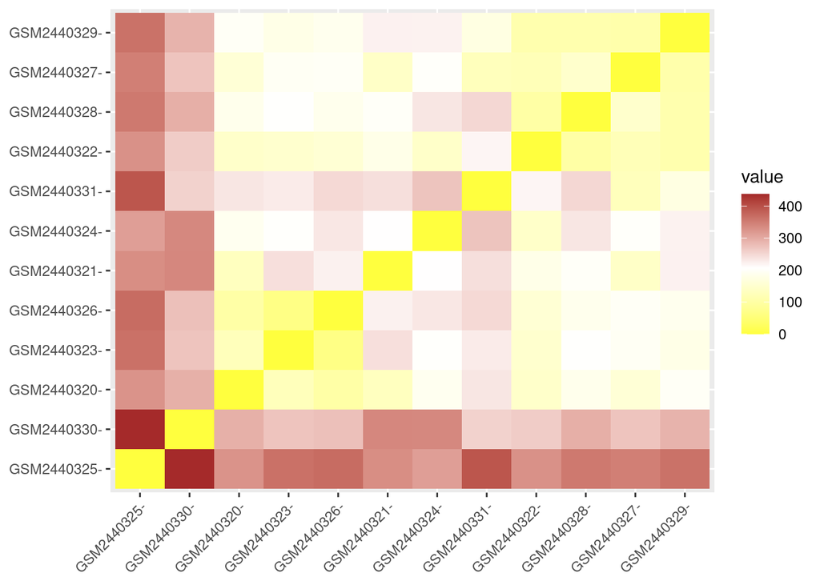

```r
distance<- get_dist(x)
fviz_dist(distance, gradient = list(low ="yellow", mid = "white", high = "brown"))
```

### Clustering jerárquico: método de Ward

Construyamos un dendrograma:

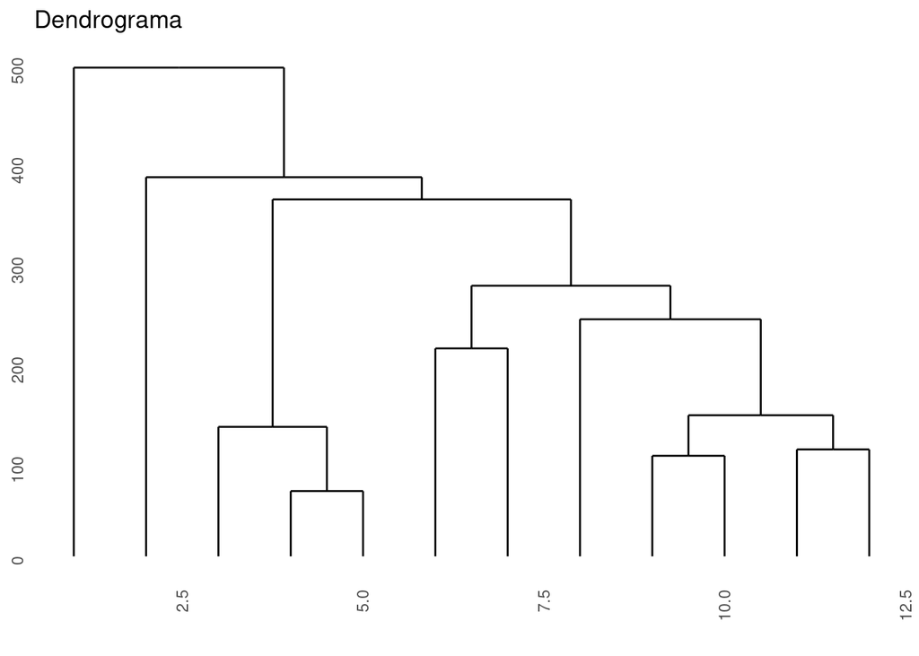

```r
dendrogram <- hclust(dist(x, method = 'euclidean'), method = 'ward.D')
ggdendrogram(dendrogram, rotate = FALSE, labels = FALSE, theme_dendro = TRUE) +
labs(title = "Dendrograma")
```

### Clustering no jerárquico: método KMeans:

Intentemos corroborar cuál podría ser el número óptimo de clusters:

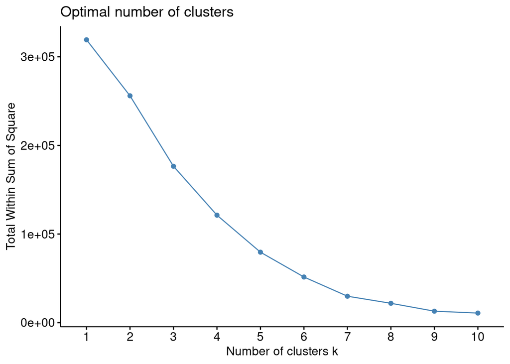

```r
set.seed(123)
fviz_nbclust(x, kmeans, method = "wss")
```

Aplicamos el algoritmo KMeans:

```r
result_kmeans <- kmeans(x, centers = 3, nstart = 25)
result_kmeans$cluster
```

```
## GSM2440320 GSM2440321 GSM2440322 GSM2440323 GSM2440324 GSM2440325 GSM2440326
##          3          3          3          3          3          1          3
## GSM2440327 GSM2440328 GSM2440329 GSM2440330 GSM2440331
##          3          3          3          2          2
```

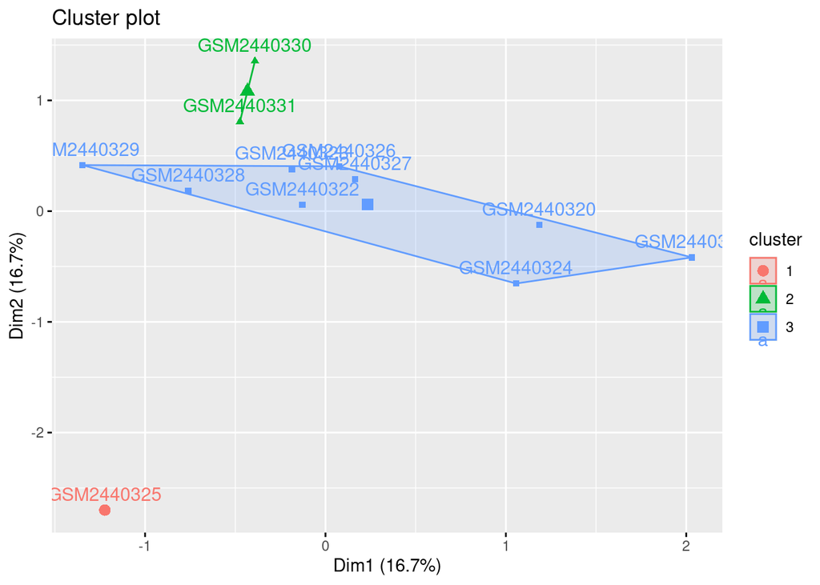

```r
fviz_cluster(result_kmeans,data=x)
```

En efecto, observamos 3 grupos bien diferenciados. Corroboramos además las conclusiones obtenidas tras el análisis de componentes pricipales.

# Análisis cluster (usando datos en crudo)

Escalamos los datos:

```r
x <- scale(data)
```

### Clustering jerárquico: método de Ward

Construyamos un dendrograma:

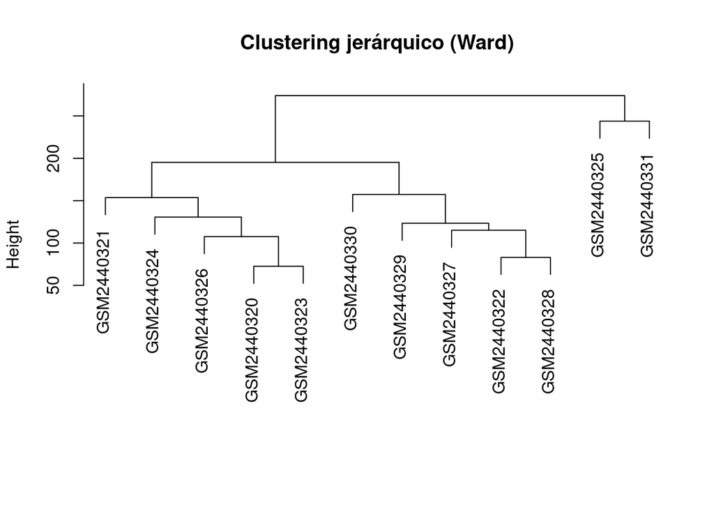

```r
# Transponemos: necesitamos muestras como filas
data_clustering <- t(x)

# Dendrograma
plot(hclust(dist(data_clustering, method = "euclidean"),
            method = "ward.D2"), labels = colnames(x),
            main = "Clustering jerárquico (Ward)", sub = "", xlab = "")
```

### Clustering no jerárquico: KMeans

Elegimos el número de clusters óptimo. Probamos con el método de la silueta:

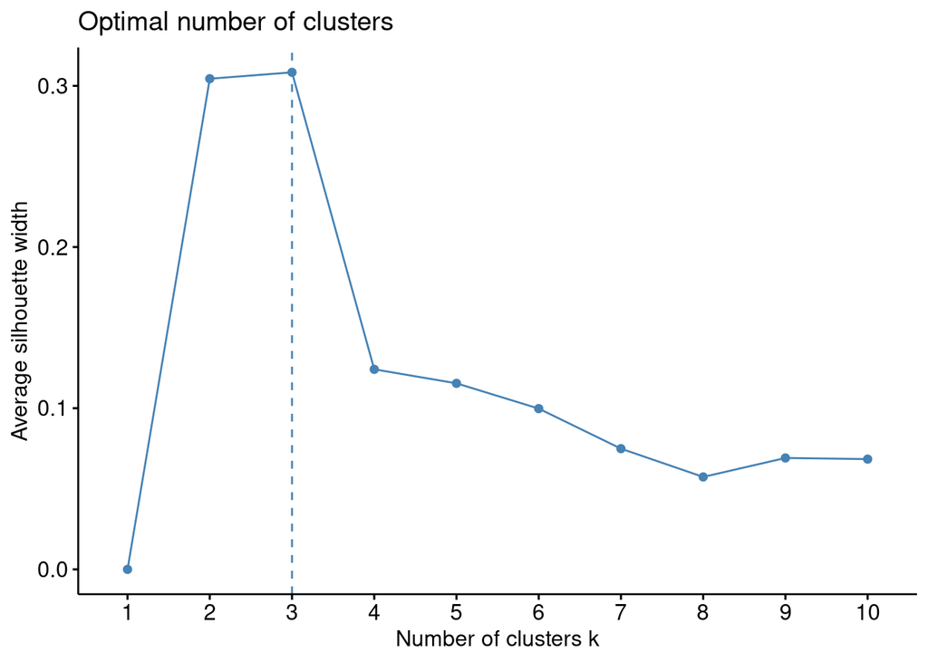

```r
set.seed(123)
fviz_nbclust(data_clustering, kmeans, method = "silhouette")
```

Y observamos que 3 es un número adecuado. Aplicamos entonces el método K-means:

```r
k_result <- kmeans(data_clustering, centers = 3, nstart = 25)
k_result$cluster
```

```
## GSM2440320 GSM2440321 GSM2440322 GSM2440323 GSM2440324 GSM2440325 GSM2440326
##          3          3          3          3          3          1          3
## GSM2440327 GSM2440328 GSM2440329 GSM2440330 GSM2440331
##          3          3          3          3          2
```

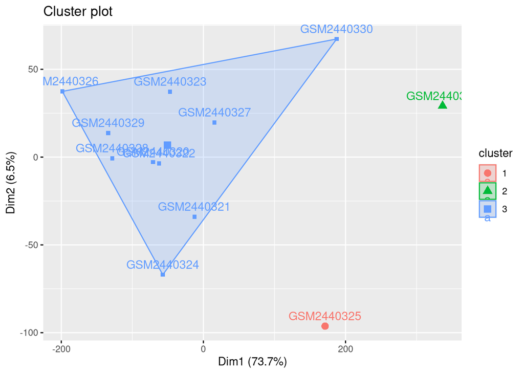

```r
fviz_cluster(k_result,data=data_clustering)
```

Obtenemos el un resultado muy parecido al que obtuvimos cuando hicimos clustering previo PCA.